# Social care model 25

David Henderson

08, March, 2019

# Introduction

Re-run models with cleaned data 2019-03-02. This is with “NULL” social care rows removed after identifying error in excess numbers for years 2014/15 and 2015/16.

This time model for councils with link rate >96%

## Packages

```r
library(finalfit)  #Easy summary and OR tables
library(tidyverse) #For ...well everything
library(magrittr)  #Pipe operators
library(lubridate) #Dates (not loaded with tidyverse)
library(broom)     #Tidy model coefficients and fit stats
library(extrafont) #For plot font options
library(margins)   #Calculate AMEs from models
library(DT)        #Print pretty tables in html with buttons
library(ggthemes)  #scale_colour_ptol()
library(ggrepel)
library(rlang)
library(glue)

#Set the base plotting options
theme_set(theme_minimal(base_size = 16))

#My own helper functions
`%nin%` <- Negate(`%in%`) #negate the %in% function
source("Research/functions/round_df.R") #Round-up all numeric values in a df
source("Research/functions/my_datatable.R") #quick datatable

#From @kjhealy's book "Data visualisation"
#Two functions to tidy up variable names in model outputs
source("Research/functions/prefix_funcs.R")

#As of October 2018 I am using margins v0.3.23. An update in
#August 2018 included the below function to summarise the margins command
#in a way that can be mapped using purrr::map. This has not been pushed
#to CRAN yet and there will be delay even after it is before it will be available
#in the safe haven. It is fairly simple so have recreated it here
source("Research/functions/margins_summary.R")

#Set breaks and labels for plots here (saves re-writing them for facet plots etc.)
year_breaks <- c(ymd(20110331), ymd(20120331), ymd(20130331),
                 ymd(20140331), ymd(20150331), ymd(20160331))

year_labels <- c(`2011-03-31` = "2010/11",
                 `2012-03-31` = "2011/12",
                 `2013-03-31` = "2012/13",
                 `2014-03-31` = "2013/14",
                 `2015-03-31` = "2014/15",
                 `2016-03-31` = "2015/16")
#Finally an expression that can be used programatically with case_when()
#note: needs library(rlang)
year_char <- exprs(
           year == ymd(20110331) ~ "2010/11",
           year == ymd(20120331) ~ "2011/12",
           year == ymd(20130331) ~ "2012/13",
           year == ymd(20140331) ~ "2013/14",
           year == ymd(20150331) ~ "2014/15",
           year == ymd(20160331) ~ "2015/16",
           year == ymd(20170331) ~ "2016/17"
)

#Set a file path for saving objects

filepath <- "Research/created_objects/models/"
```

## Load data

Using the `thesis` object. Created Feb 2019 with additional SC cleaning

```r
load("Research/created_objects/clean_data/thesis.rds")
```

## Tidy up

```r
thesis %<>%
  filter(link_grp == "96-99.9%") %>%
  filter(is.na(dod)) %>%
  filter(!(scs_flag == "No Social Care" & care_home == "Care home")) %>%
  #Drop variables not in the model
  select(index, year, scs_flag, sex, age_grp, simd, meds_grp, council)

council_names <- c("Falkirk", "Angus", "East Ayrshire", "Inverclyde",
                   "South Lanarkshire", "Stirling", "North Ayrshire",
                   "Dumfries and Galloway", "Argyll and Bute")

thesis$council <- factor(thesis$council,
                         levels = council_names,
                         labels = council_names)
```

# Social Care Model 25

## Summarise variables

- Create a summary table. I want a summary table for each year of data.

```r
#Name variables
explanatory = c("sex", "age_grp", "simd", "meds_grp", "council")
dependent = "scs_flag"
#Nest dataframe by year then apply summary_factorlist()
thesis %>%
  group_by(year) %>%
  nest(.key = "year_data") %>%
  mutate(tab = map(year_data,
                   summary_factorlist,
                   dependent, explanatory,
                   add_dependent_label = TRUE,
                   dependent_label_prefix = "",
                   p = TRUE,
                   total_col = TRUE)) -> sc_table_1
#Pull correct labels out into a vector
V1_labels <- sc_table_1$tab[[1]][[2]]
#Apply these labels repeatedly for the 5 year of data and
#drop uneccessary empty variables. Also rename year data to better labels
sc_table_1 %<>%
  unnest(tab, .drop = TRUE) %>%
  arrange(year) %>%
  mutate(V1 = rep(V1_labels,5),
         year = case_when(!!!year_char)) %>%
  select(-(V2:V5))
```

Print out a table for 2015/16 only (not including council names)

```r
sc_table_1 %>%
  filter(year == "2015/16") %>%
  my_datatable(.)
```

|  | year | scs_flag | V1 | No Social Care | Social Care | Total | p |
| --- | --- | --- | --- | --- | --- | --- | --- |
| 1 | 2015/16 | sex | Male | 97151 (91.7) | 8834 (8.3) | 105985 | &lt;0.001 |
| 2 | 2015/16 |  | Female | 109096 (85.0) | 19311 (15.0) | 128407 |  |
| 3 | 2015/16 | age_grp | 65-69 | 71604 (97.1) | 2129 (2.9) | 73733 | &lt;0.001 |
| 4 | 2015/16 |  | 70-74 | 53870 (94.6) | 3052 (5.4) | 56922 |  |
| 5 | 2015/16 |  | 75-79 | 40083 (89.2) | 4867 (10.8) | 44950 |  |
| 6 | 2015/16 |  | 80-84 | 24936 (78.2) | 6970 (21.8) | 31906 |  |
| 7 | 2015/16 |  | 85-89 | 11302 (63.2) | 6593 (36.8) | 17895 |  |
| 8 | 2015/16 |  | 90-94 | 3579 (50.4) | 3523 (49.6) | 7102 |  |
| 9 | 2015/16 |  | 95 plus | 873 (46.3) | 1011 (53.7) | 1884 |  |
| 10 | 2015/16 | simd | 1 | 15102 (83.1) | 3066 (16.9) | 18168 | &lt;0.001 |

[output cut: 22 more lines]

Now print out a table for all years but *only* with council percentages. I’ve created my own table rather than use `finalfit` as I need to do some wrangling to get it in the format I want. It isn’t obvious here but all values are percentages of people receiving social care in each LA. I need this table as the AMEs (reported below) show differences from the reference group. For most variables this doesn;t change much but some reference LAs have quite a variation over time.

```r
thesis %>%
  group_by(year, council, scs_flag) %>%
  count %>%
  group_by(year, council) %>%
  mutate(pct = round(n/sum(n)*100, 1)) %>%
  gather(variable, value, -(year:scs_flag)) %>%
  spread(year, value) %>%
  filter(scs_flag == "Social Care" & variable == "pct") %>%
  select(-scs_flag, -variable) -> sc_table_2

year_breaks <- as.character(year_breaks)
names(sc_table_2) <- str_replace(names(sc_table_2), year_breaks, year_labels)

#sc_table_2
my_datatable(sc_table_2)
```

|  | council | 2011/12 | 2012/13 | 2013/14 | 2014/15 | 2015/16 |
| --- | --- | --- | --- | --- | --- | --- |
| 1 | Falkirk | 14.1 | 15 | 14.8 | 15.2 | 14.5 |
| 2 | Angus | 15.1 | 13.8 | 13.5 | 13.7 | 11.8 |
| 3 | East Ayrshire | 12.9 | 13.3 | 13.2 | 13.8 | 13.9 |
| 4 | Inverclyde | 12.1 | 12.5 | 12.4 | 13.1 | 15.1 |
| 5 | South Lanarkshire | 11.7 | 11.4 | 12.4 | 13 | 11.9 |
| 6 | Stirling | 10.9 | 11.1 | 11.8 | 12.2 | 12.3 |
| 7 | North Ayrshire | 10.8 | 11 | 11.1 | 11.4 | 11.7 |
| 8 | Dumfries and Galloway | 8.4 | 8 | 7.5 | 8.1 | 9.1 |
| 9 | Argyll and Bute | 8.2 | 8.7 | 9.2 | 9.6 | 9.6 |

## Fit the model to all years

First need to coerce `simd` to a numeric variable for modelling. I also need its mean value to help interpret APEs later

```r
thesis %<>%
  mutate(simd = as.numeric(simd))

thesis %>%
  summarise(mean_simd = mean(simd),
            sd_simd = sd(simd))
```

| mean_simd | sd_simd |
| --- | --- |
| 5.218311 | 2.593172 |

Now I am going to use the `or_plot()` function from `finalfit` to produce a nice plot showing odds ratios. As this isn’t a `ggplot` I can’t save it in the normal manner so will use the `png()` function instead. This means it won’t render in the html but I’ll leave the code in here for reference.

Formula for this model: `glm(scs_flag ~ sex*age_grp + simd*meds_grp + age_grp*meds_grp + council*simd)`

```r
start <- Sys.time()
#Name variables
explanatory = c("sex*age_grp", "simd*meds_grp",
                "age_grp*meds_grp", "council*simd")
dependent = "scs_flag"

png("Research/created_objects/plots/sc_model_25_or_plot.png",
    width = 12, height = 9, units = "in", res = 300)

thesis %>%
  filter(year == ymd(20160331)) %>%
  mutate(scs_flag = ff_label(scs_flag, "Any social care"),
         sex = ff_label(sex, "Sex"),
         age_grp = ff_label(age_grp, "Age group"),
         simd = ff_label(simd, "SIMD"),
         meds_grp = ff_label(meds_grp, "Repeat medicine group"),
         council = ff_label(council, "Local Authority")) %>%
  or_plot(dependent, explanatory,
          dependent_label = "Any Social Care 2015/16",
          breaks = c(0.5, 1, 5, 10, 20 , 50, 100))

dev.off()
print(Sys.time()-start)
```

1.85 hrs to run this

Whilst this is lovely, what I really want in marginal effects for *every* year of data. Can’t use `finalfit` here, but will code in myself with some data wrangling so that all results are stored in a dataframe.

```r
start <- Sys.time()

#Create a function for the model
sc_model <- function(my_df){
  glm(scs_flag ~                                #The formula for the model
        sex*age_grp +
        simd*meds_grp +
        age_grp*meds_grp +
        council*simd,
      family = binomial(),                      #Logistic regression
      data = my_df)                             #identify which data to use
  }


sc_model_25 <-
  thesis %>%  #Main dataframe
  group_by(year) %>%
  #Nest data for each year
  nest(.key = "year_data") %>%
  #Create model column using above function
  mutate(mod_var = map(year_data, sc_model),
         #Tidy coefficients using broom::tidy into a column
         tidy_var = map(mod_var, tidy),
         #compute AMEs and add as a column
         marginals = map2(mod_var, year_data, ~margins_summary(.x, data = .y)))

print(Sys.time()-start)
```

```r
save(sc_model_25, file = "Research/created_objects/models/sc_model_25.rds")
```

*Note: Time difference = 3.1 hrs*

## Model results

```r
sc_model_25 %>%
  filter(year == ymd(20160331)) %>%
  unnest(tidy_var, .drop = TRUE) %>%
  #exponentiate the coefficents for OR
  mutate(odds_ratio = exp(estimate),
         #Calculate Lower CI and exponentiate
         conf_int_low = exp(estimate - 1.96*std.error),
         #Calculate Upper CI and exponentiate
         conf_int_high = exp(estimate + 1.96*std.error)) %>%
  round_df(., dig = 3) %>%
  mutate(p.value = as.character(p.value),
         p.value = if_else(p.value == "0", "<0.001", p.value)) -> tidy_tab

#Tidy up labels
prefixes <- c("sex", "scs_flag", "usc_flag", "care_home")
tidy_tab$term <- prefix_strip(tidy_tab$term, prefixes)
tidy_tab$term <- prefix_replace(tidy_tab$term, "Meds_grp",
                                       "Meds: ")
tidy_tab$term <- prefix_replace(tidy_tab$term,
                                       "Age_grp", "Age: ")
tidy_tab$term <- prefix_replace(tidy_tab$term,
                                       "Simd", "SIMD Decile: ",
                                       toTitle = FALSE)

tidy_tab
```

| year | term | estimate | std.error | statistic | p.value | odds_ratio | conf_int_low | conf_int_high |
| --- | --- | --- | --- | --- | --- | --- | --- | --- |
| 2016-03-31 | (Intercept) | -4.251 | 0.103 | -41.165 | <0.001 | 0.014 | 0.012 | 0.017 |
| 2016-03-31 | Female | 0.152 | 0.045 | 3.355 | 0.001 | 1.164 | 1.065 | 1.272 |
| 2016-03-31 | Age: 70-74 | 0.674 | 0.111 | 6.070 | <0.001 | 1.962 | 1.578 | 2.439 |
| 2016-03-31 | Age: 75-79 | 1.544 | 0.104 | 14.860 | <0.001 | 4.684 | 3.821 | 5.742 |
| 2016-03-31 | Age: 80-84 | 2.539 | 0.099 | 25.528 | <0.001 | 12.666 | 10.422 | 15.391 |
| 2016-03-31 | Age: 85-89 | 3.560 | 0.102 | 35.006 | <0.001 | 35.174 | 28.817 | 42.934 |
| 2016-03-31 | Age: 90-94 | 4.464 | 0.118 | 37.937 | <0.001 | 86.818 | 68.937 | 109.337 |
| 2016-03-31 | Age: 95 Plus | 4.836 | 0.180 | 26.931 | <0.001 | 125.909 | 88.556 | 179.019 |
| 2016-03-31 | SIMD Decile: | -0.135 | 0.012 | -11.030 | <0.001 | 0.874 | 0.853 | 0.895 |
| 2016-03-31 | Meds: 3-5 | 0.898 | 0.110 | 8.173 | <0.001 | 2.455 | 1.979 | 3.044 |

[output cut: 45 more lines]

```r
#my_datatable(tidy_tab)
```

## Model fit

### Fit statistics

Create new list column to model object with fit statistics using `broom::glance`

```r
sc_model_25 %<>%
  mutate(glance_var = map(mod_var, glance))
```

Now I need to mannually calcluate McFadden’s pseudo $R^{2}$ which has the formula:

$$R^{2}_{McFadden} = 1 - \frac {ln(LM_{1})}{ln(LM_{0})}$$

Where $ln(LM_{1})$ is the log likelihood value for the fitted model and $ln(LM_{0})$ is the log likelihood for the null model with only an intercept as a predictor.

Calculate the pseudo $R^2$, then rearrange variable order whilst dropping unwanted variables from glance - Print this out - will need reported.

```r
sc_model_25 %>%
  unnest(glance_var, .drop = TRUE) %>%
  mutate(pseud_r2 = 1 - (logLik / (null.deviance / -2)), #Calculate McFadden's
         year = case_when(!!!year_char)) %>%
  select(year, pseud_r2, everything()) %>%
  round_df(dig = 3) -> gof_tab

#gof_tab
my_datatable(gof_tab)
```

|  | year | pseud_r2 | null.deviance | df.null | logLik | AIC | BIC | deviance | df.residual |
| --- | --- | --- | --- | --- | --- | --- | --- | --- | --- |
| 1 | 2012/13 | 0.222 | 160148.076 | 224053 | -62313.309 | 124736.619 | 125304.199 | 124626.619 | 223999 |
| 2 | 2013/14 | 0.222 | 165344.874 | 228780 | -64297.777 | 128705.553 | 129274.282 | 128595.553 | 228726 |
| 3 | 2014/15 | 0.233 | 171893.338 | 231670 | -65924.654 | 131959.309 | 132528.728 | 131849.309 | 231616 |
| 4 | 2015/16 | 0.236 | 172080.12 | 234391 | -65721.97 | 131553.94 | 132124.002 | 131443.94 | 234337 |
| 5 | 2011/12 | 0.218 | 156192.796 | 218389 | -61046.073 | 122202.147 | 122768.319 | 122092.147 | 218335 |

Anything with pseudo $R^2$ 0.2-0.4 is considered a very good fit

### Residual assessment

Not excpecting normally distributed residuals or constant variance as I am using a non-linear model. However, can have a look at the deviance residual to see if indiviudal points are not well fitted.

I use `augment()` from `broom` to find values then plot the standardised residuals to see how many exceed 3 standard deviations.

I won’t be formally reporting this (hence non-tidied plot) but need to have a look and will probably mention it whilst discussing results. I am using 2011/12 as a reference year here as it had the poorest fit

```r
sc_model_25 %<>%
  mutate(aug_var = map(mod_var, augment))
```

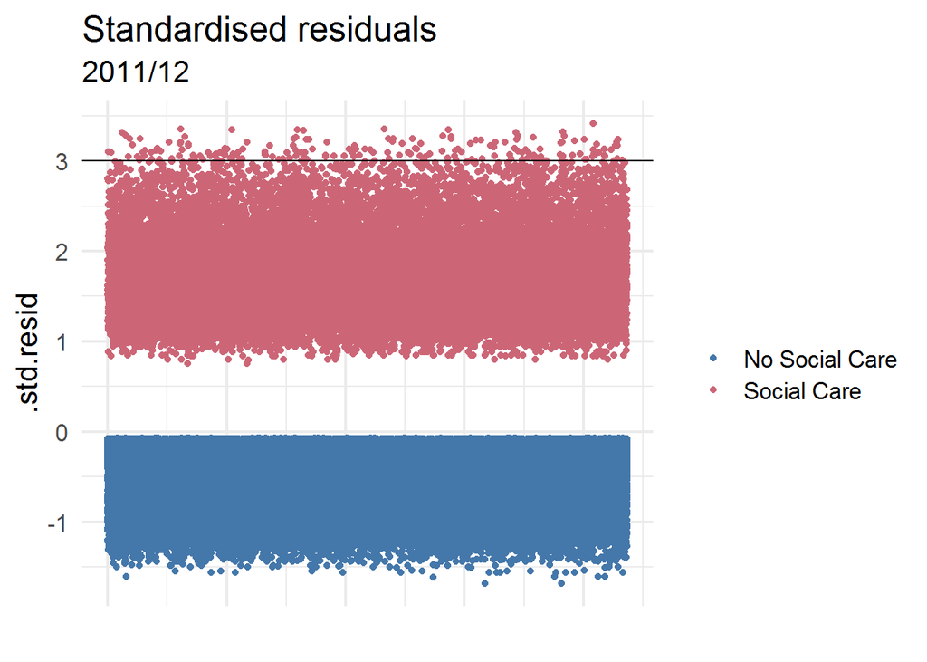

```r
sc_model_25 %>%
  filter(year == ymd(20120331)) %>%
  unnest(.$aug_var) %>%
  mutate(index = 1:n())-> aug_data_1112

aug_data_1112 %>%
  ggplot(aes(index, .std.resid, colour = scs_flag)) +
  geom_point() +
  geom_hline(yintercept = 3) +
  scale_colour_ptol() +
  theme(axis.text.x = element_blank()) + #supress index for SDC
  labs(title = "Standardised residuals",
       subtitle = "2011/12",
       colour = "",
       x = "")
```

I can look specifically at the rows that have observations with a poor fit. I think it would be pretty hard to suggest this table is disclosive, however there could be some debate about that. Again, I’m not going to be explicitly reporting it but more likely to allude to it.

For that reason, I won’t render it here - saves a potential disclosure delay.

```r
aug_data_1112 %>%
  filter(.std.resid > 3) %>%
  round_df(dig = 3)
```

183 rows from 218,390 (0.08%) for indivudals with outlying standardised residuals. These obserations that had a poor model fit are all for people that received social care but were only prescribed between 0-2 medicines or, in a few cases, 3-5 meds.

All were below average age (<74) and the majority were in the 65-69 age group.

I dropped data on “Client Group” from the Social Care Survey as it was really poorly coded and didn’t tie up with metadata. This is a shame as I have a theory that these (very few) observations with poor fit are potentially people with learning disabilities. I wouldn’t be able to model them out but it would be nice to be able to identify if I am right/wrong.

## Marginal effects

Now to look at AMEs

```r
sc_model_25 %>%
  unnest(marginals) %>%
  round_df(dig = 3) %>%
  arrange(year, AME) -> sc_marginal_25

#Tidy up labels
prefixes <- c("sex")
sc_marginal_25$factor <- prefix_strip(sc_marginal_25$factor, prefixes)
sc_marginal_25$factor <- prefix_replace(sc_marginal_25$factor, "Meds_grp",
                                       "Meds: ")
sc_marginal_25$factor <- prefix_replace(sc_marginal_25$factor,
                                       "Age_grp", "Age: ")
sc_marginal_25$factor <- prefix_replace(sc_marginal_25$factor,
                                       "Simd", "SIMD Decile: ",
                                       toTitle = FALSE)
sc_marginal_25$factor <- prefix_replace(sc_marginal_25$factor,
                                       "council", "")
#sc_marginal_25
my_datatable(sc_marginal_25)
```

|  | year | factor | AME | SE | z | p | lower | upper |
| --- | --- | --- | --- | --- | --- | --- | --- | --- |
| 1 | 2012-03-31 | Dumfries and Galloway | -0.052 | 0.003 | -20.535 | 0 | -0.057 | -0.047 |
| 2 | 2012-03-31 | Argyll and Bute | -0.051 | 0.003 | -17.313 | 0 | -0.057 | -0.046 |
| 3 | 2012-03-31 | Inverclyde | -0.036 | 0.003 | -11.825 | 0 | -0.042 | -0.03 |
| 4 | 2012-03-31 | North Ayrshire | -0.033 | 0.003 | -12.122 | 0 | -0.039 | -0.028 |
| 5 | 2012-03-31 | South Lanarkshire | -0.031 | 0.002 | -12.947 | 0 | -0.035 | -0.026 |
| 6 | 2012-03-31 | Stirling | -0.02 | 0.003 | -5.812 | 0 | -0.027 | -0.013 |
| 7 | 2012-03-31 | East Ayrshire | -0.016 | 0.003 | -5.318 | 0 | -0.022 | -0.01 |
| 8 | 2012-03-31 | SIMD Decile: | -0.007 | 0 | -27.233 | 0 | -0.008 | -0.007 |
| 9 | 2012-03-31 | Age: 70-74 | 0.021 | 0.001 | 16.012 | 0 | 0.019 | 0.024 |
| 10 | 2012-03-31 | Angus | 0.028 | 0.003 | 8.343 | 0 | 0.021 | 0.035 |

[output cut: 85 more lines]

## Plot marginal effects

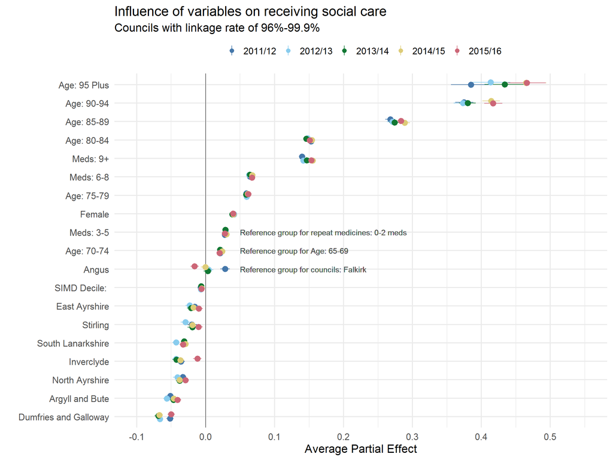

```r
sc_marginal_25 %>%
  ggplot(aes(reorder(factor, AME), AME,
             ymin = lower, ymax = upper,
             colour = factor(year))) +
  geom_hline(yintercept = 0, colour = "#555555") +
  geom_pointrange(fatten = 6, position = position_jitter(width = 0.15)) +
  geom_text(aes(x = "Angus", y= 0.05),
             label = "Reference group for councils: Falkirk",
             colour = "#555555",
             hjust = 0) +
  geom_text(aes(x = "Age: 70-74", y= 0.05),
             label = "Reference group for Age: 65-69",
             colour = "#555555",
             hjust = 0) +
  geom_text(aes(x = "Meds: 3-5", y = 0.05),
             label = "Reference group for repeat medicines: 0-2 meds",
             colour = "#555555",
             hjust = 0) +
  coord_flip() +
  scale_colour_ptol(labels = year_labels) +
  scale_y_continuous(limits = c(-0.1, 0.55),
                     breaks = scales::pretty_breaks(n = 8)) +
  theme(legend.position = "top") +
  labs(x = "",
       y= "Average Partial Effect",
       colour = "",
       title = "Influence of variables on receiving social care",
       subtitle = "Councils with linkage rate of 96%-99.9%") -> sc_model_25_AME_plot

sc_model_25_AME_plot
```

## Council over time

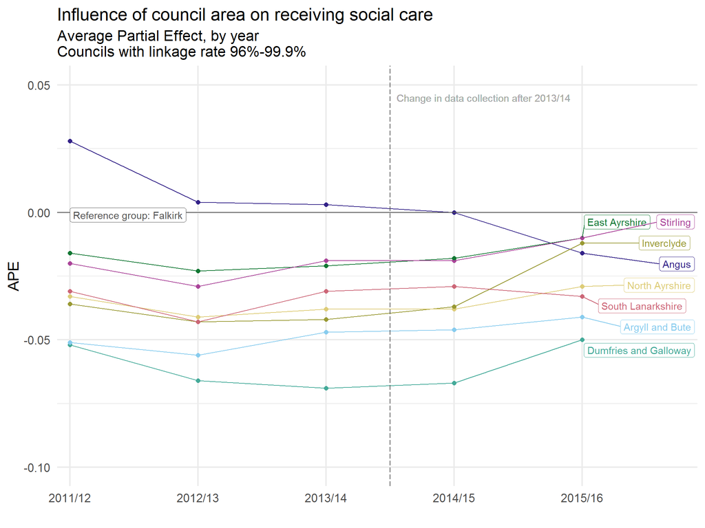

```r
sc_marginal_25 %<>%
  mutate(year = case_when(!!!year_char))

sc_marginal_25 %>%
  filter(factor %in% council_names) %>%
  mutate(label = if_else(year == max(year),
                         as.character(factor), NA_character_)) %>%
  ggplot(aes(year, AME,
             group = factor,
             colour = factor)) +
  geom_point(size = 2) +
  geom_path() +
  geom_hline(yintercept = 0, colour = "#555555") +
  geom_vline(xintercept = 3.5, linetype = "longdash", colour = "grey30") +
  geom_label_repel(aes(label = label), nudge_x = 2) +
  geom_label(aes(x = "2011/12", y = -0.001),
             label = "Reference group: Falkirk",
             colour = "#555555",
             hjust = 0) +
  geom_text(aes(x = 3.55, y= 0.045),
            label = "Change in data collection after 2013/14",
            colour = "#AAAAAA",
            hjust = 0) +
  scale_colour_ptol(guide = "none") +
  scale_y_continuous(limits = c(-0.1, 0.05),
                     breaks = scales::pretty_breaks()) +
  scale_x_discrete(expand = expand_scale(add = c(0.1, 0.9))) +
  labs(x = "",
       y = "APE",
       title = "Influence of council area on receiving social care",
       subtitle = "Average Partial Effect, by year\nCouncils with linkage rate 96%-99.9%") -> sc_model_25_council_APE_plot
sc_model_25_council_APE_plot
```

## Plot SIMD

SIMD id different from the rest as it is modelled as a continuous variable. I’m going to produce a separate plot for it to make interpretation easier.

```r
sc_model_25 %<>%
  mutate(cplot_simd = map2(mod_var, year_data,
                           ~cplot(.x, data = .y, x = "simd", draw=FALSE)))
```

```r
sc_model_25 %>%
  filter(year == ymd(20160331)) %>%
  unnest(cplot_simd) %>%
  round_df(., dig=3) %>%
  my_datatable(.)
```

|  | year | xvals | yvals | upper | lower |
| --- | --- | --- | --- | --- | --- |
| 1 | 2016-03-31 | 1 | 0.024 | 0.027 | 0.021 |
| 2 | 2016-03-31 | 1.375 | 0.023 | 0.026 | 0.02 |
| 3 | 2016-03-31 | 1.75 | 0.023 | 0.025 | 0.02 |
| 4 | 2016-03-31 | 2.125 | 0.022 | 0.025 | 0.019 |
| 5 | 2016-03-31 | 2.5 | 0.021 | 0.024 | 0.019 |
| 6 | 2016-03-31 | 2.875 | 0.021 | 0.023 | 0.018 |
| 7 | 2016-03-31 | 3.25 | 0.02 | 0.022 | 0.018 |
| 8 | 2016-03-31 | 3.625 | 0.02 | 0.022 | 0.017 |
| 9 | 2016-03-31 | 4 | 0.019 | 0.021 | 0.017 |
| 10 | 2016-03-31 | 4.375 | 0.018 | 0.02 | 0.016 |

[output cut: 15 more lines]

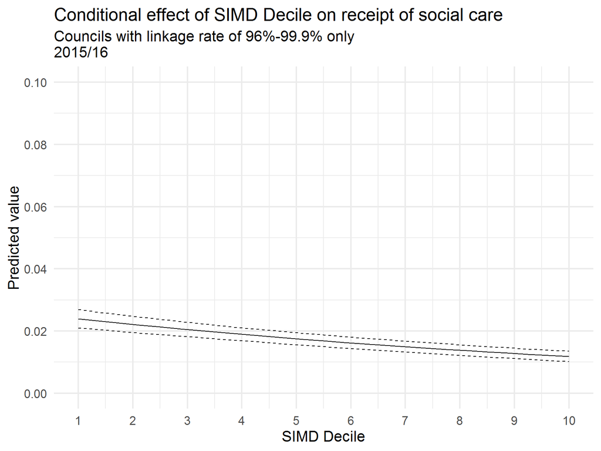

```r
sc_model_25 %>%
  filter(year == ymd(20160331)) %>%
  unnest(cplot_simd) %>%
  ggplot(aes(x = xvals)) +
  geom_line(aes(y = yvals)) +
  geom_line(aes(y = upper), linetype = 2) +
  geom_line(aes(y = lower), linetype = 2) +
  scale_x_continuous(breaks = scales::pretty_breaks(n = 10)) +
  scale_y_continuous(breaks = scales::pretty_breaks(),
                     limits = c(0,0.1)) +
  labs(title = "Conditional effect of SIMD Decile on receipt of social care",
       subtitle = "Councils with linkage rate of 96%-99.9% only\n2015/16",
       x = "SIMD Decile",
       y = "Predicted value") -> sc_model_25_simd_plot
sc_model_25_simd_plot
```